# Тестовое задание

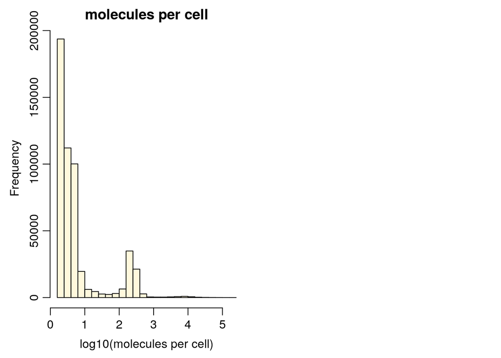

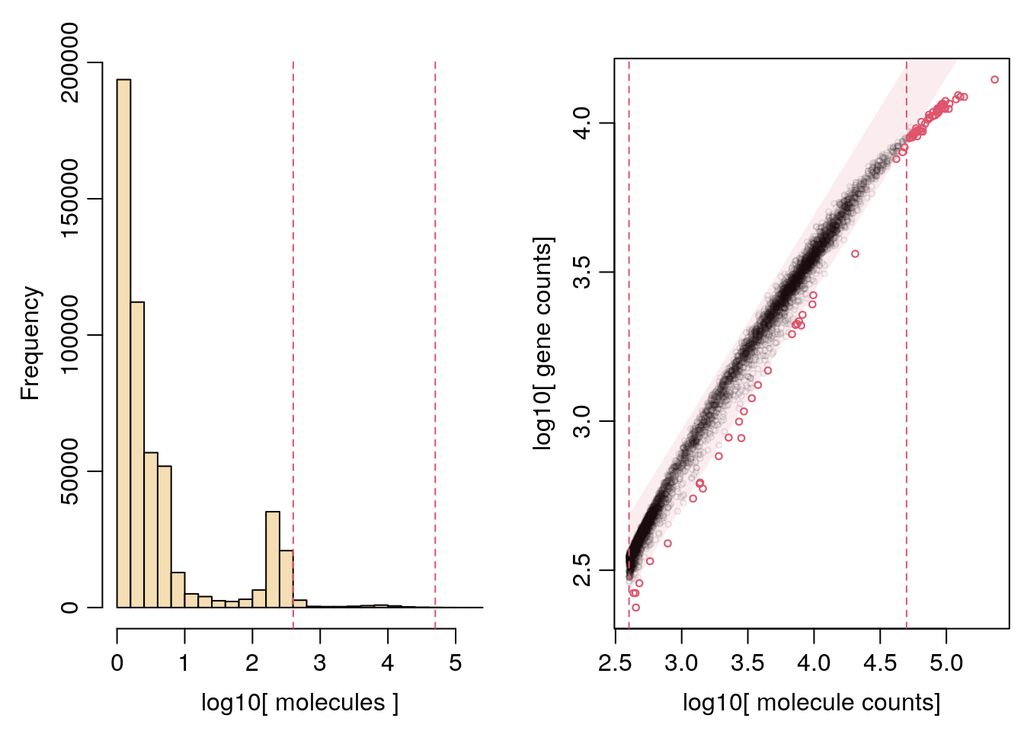

```r
hist(log10(colSums(data124)+1), main='molecules per cell', col='cornsilk', xlab='log10(molecules per cell)')
data124_400 <- gene.vs.molecule.cell.filter(data124, min.cell.size=400)
```

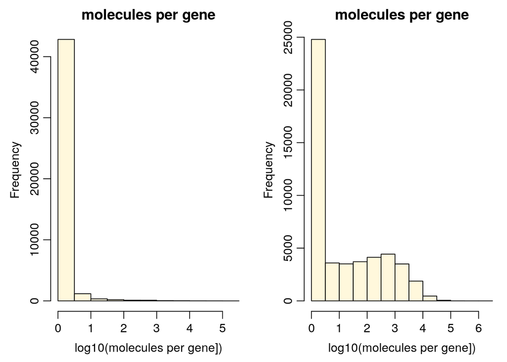

```r
#Строим распределение подсчетов на ген, находим слабо экспресируемые гены и удаляем их
hist(log10(rowSums(data117_400)+1), main='molecules per gene', col='cornsilk', xlab='log10(molecules per gene])')
data117_400 <- data117_400[rowSums(data117_400)>=1, ]

hist(log10(rowSums(data124_400)+1), main='molecules per gene', col='cornsilk', xlab='log10(molecules per gene])')
```

```r
data124_400 <- data124_400[rowSums(data124_400)>=2, ]
```

После фильтрации:

```r
dim(data124_400)
```

```
## [1] 26455  6740
```

```r
dim(data117_400)
```

```
## [1] 8150 3406
```

Датасет 117 очень низкого качетва, вполне возможно, что его следует исключить из дальнейшего анализа.

### Предварительная обработка.

Создаем объект padoda2 для датасетов. Производиться нормализация размеров библиотек и корректировка дисперсии (нормализоация влияния генов с разными величинами экспрессии). Идентифицируются сверхдисперсные гены (2000 генов).

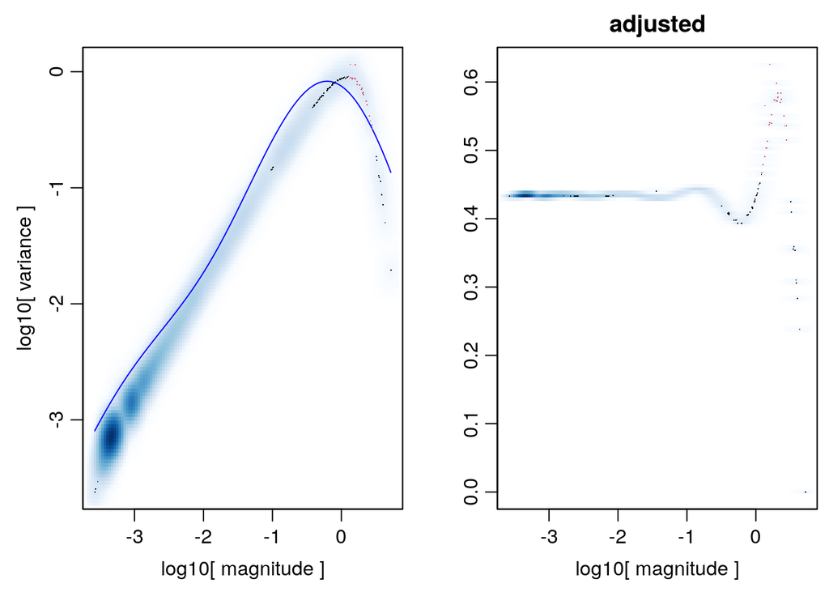

```r
# конвертация матриц в необходимый формат

data117_400 <- as(data117_400, "dgCMatrix")
data124_400 <- as(data124_400, "dgCMatrix")

r117 <- Pagoda2$new(data117_400,log.scale = TRUE, n.cores=4)
r117$adjustVariance(plot=TRUE, gam.k=10)
```

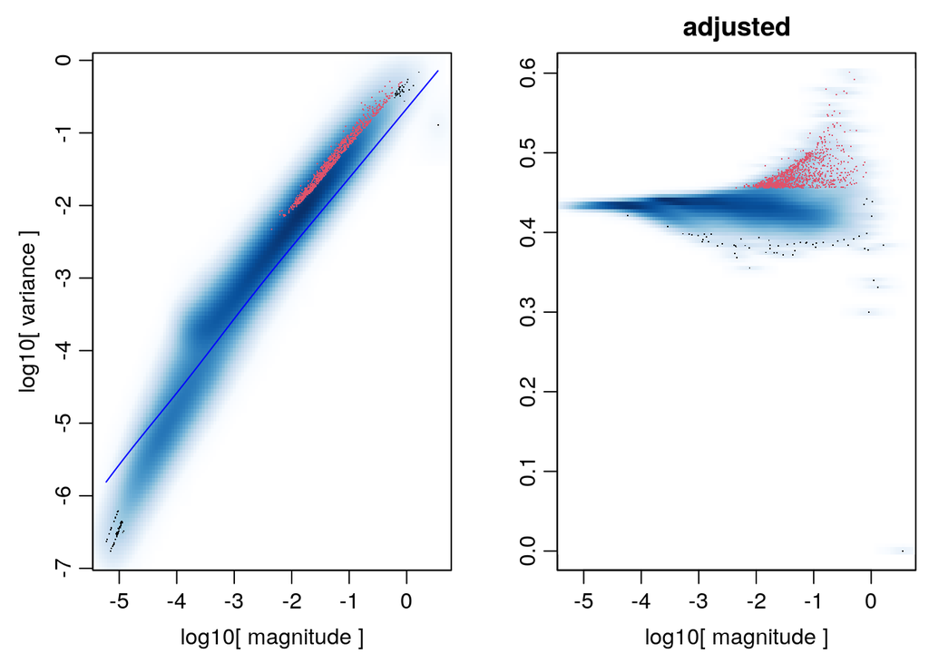

```r
r124 <- Pagoda2$new(data124_400,log.scale = TRUE, n.cores=4)
r124$adjustVariance(plot=TRUE, gam.k=10)
```

```r
# уменьшаем размеры набора данных c помощью PCA

r117$calculatePcaReduction(n.odgenes=2e3)
r124$calculatePcaReduction(n.odgenes=2e3)

# строится граф и находятся кластера
r124$makeKnnGraph(k=40, type='PCA', center=TRUE, distance='cosine')
```

```
## creating space of type angular done
## adding data ... done
## building index ... done
## querying ... done
```

```r
r117$makeKnnGraph(k=40, type='PCA', center=TRUE, distance='cosine')
```

```
## creating space of type angular done
## adding data ... done
## building index ... done
## querying ... done
```

```r
r117$getKnnClusters(method=infomap.community, type='PCA')
r124$getKnnClusters(method=infomap.community, type='PCA')

#Нахождение вложений и кластеров
M <- 30
r117$getEmbedding(type='PCA', embeddingType = 'largeVis', M=M, perplexity=30, gamma=1/M, alpha=1)
r117$getEmbedding(type='PCA', embeddingType='tSNE', perplexity=10,verbose=FALSE)
r124$getEmbedding(type='PCA', embeddingType = 'largeVis', M=M, perplexity=30, gamma=1/M, alpha=1)
r124$getEmbedding(type='PCA', embeddingType='tSNE', perplexity=10,verbose=FALSE)

r124$getKnnClusters(method=multilevel.community, type='PCA', name='multilevel')
r117$getKnnClusters(method=multilevel.community, type='PCA', name='multilevel')
```

### Объединение датасетов с помощью conos. Устранение batc-эффекта.

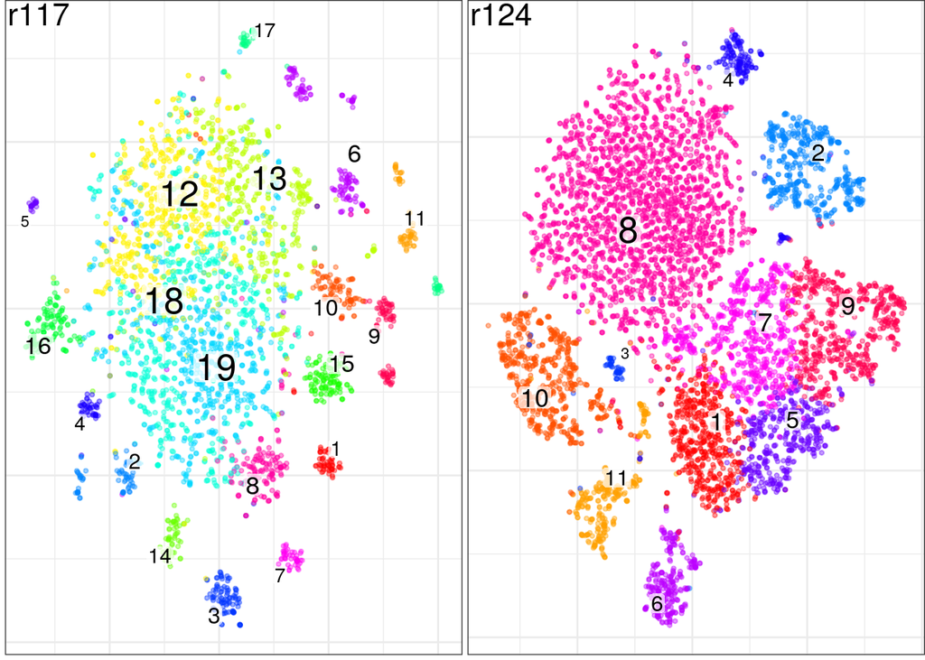

```r
panel <- list("r117" = r117, "r124" = r124)
con <- Conos$new(panel, n.cores=4)
# визуализация для каждого из датасетов
con$plotPanel(clustering="multilevel", use.local.clusters=TRUE, title.size=6)
```

```r
# Построение объединенного графа и общего PCA
con$buildGraph(k=30, k.self=5, space='PCA', ncomps=30, n.odgenes=2000, matching.method='mNN', metric='angular', score.component.variance=TRUE, verbose=TRUE)
```

```
## ...
```

```r
# нахождение общих кластеров
con$findCommunities(method=leiden.community, resolution=0.5)
con$findCommunities(method = igraph::walktrap.community, steps=7)

# получаем объединенную матрицу
mat <- t(con$getJointCountMatrix())
```

## Аннотация клеток с помощью cellAnnotatoR.

cellAnnotatoR работает на основе пакета Pagoda2, который использовался выше в анализе. Этот анотатор показывает высокую точность работы и что немаловажно, очень быстро работает. Но для его работы необходимо заранее знать какие клеточные типы должны быть определены, и какие гены им соответствуют. Для данного датасета, был создан файл kidney1.md, с предполагаемыми клеточными типами и генами. Данные были взяты из статьи (https://www.nature.com/articles/s41597-019-0351-8#Abs1).

```r
marker_path1 <- "/home/kvergasova/An/single_cell/kidney1.md"

marker_list <- parseMarkerFile(marker_path1)

p1 <- basicP2proc(mat,n.cores=4, min.cells.per.gene = 0, n.odgenes = 2e3,
                  get.largevis = FALSE, make.geneknn = FALSE, get.tsne = T)
```

```
## creating space of type angular done
## adding data ... done
## building index ... done
## querying ... done
```

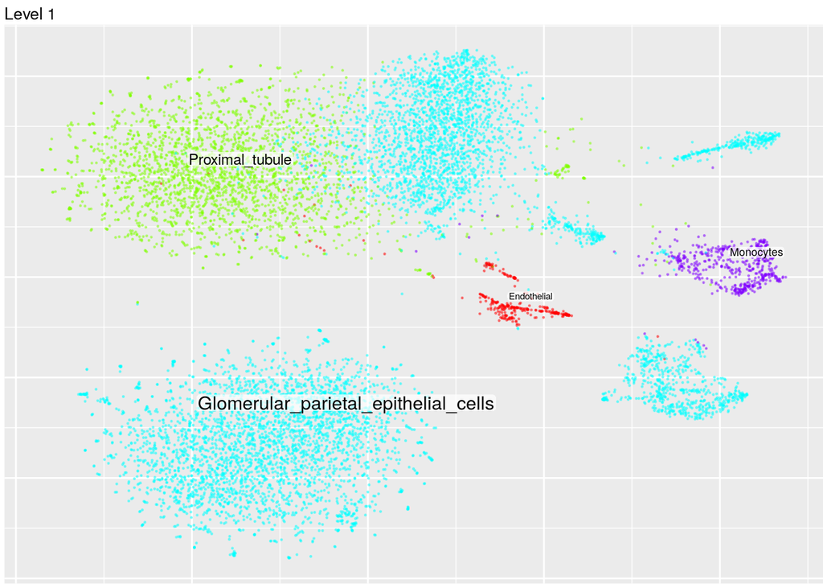

```r
p1$getKnnClusters(type="PCA", method=conos::leiden.community, resolution=1, n.iterations=10, name="leiden")

clf_data1 <- getClassificationData(mat, marker_list, prenormalized=T)
ann_by_level1 <- assignCellsByScores(p1$graphs$PCA, clf_data1, clusters=p1$clusters$PCA$leiden)
plotAnnotationByLevels(p1$embeddings$PCA$tSNE, ann_by_level1$annotation, size=0.2,
                       font.size=c(2, 4), shuffle.colors=T)
```

```r
table(ann_by_level1$annotation)
```

```
##
##                          Endothelial Glomerular_parietal_epithelial_cells
##                                  313                                 6746
##                            Monocytes                      Proximal_tubule
##                                  500                                 2587
```

Всего удалось выделилось 4 клеточных типа Больше всего glomerular parietal epithelial cell 66% Затем Proximal_tubule cells 25% Затем Monocytes 5% Endothelial cells 3%

Полученные соотношения клеточных типов заметно отличаются от данных для здоровой почки из статьи (https://www.nature.com/articles/s41597-019-0351-8#Abs1): Proximal_convoluted_tubule cell ~ 50% Proximal_tubule cells ~ 32% Proximal_straight_tubule cells ~ 5% NK-T cell ~ 5% Monocutes ~ 3% glomerular parietal epithelial cell ~ 3% Distal_tubule cell ~ 2% Collecting_duct_principal_cells ~ 0.7% B cells ~ 0.6% Collecting_duct_intercalated_cells ~ 0.3%

Основное отличие проаннотированных клеток от здоровых, заключается в явном доминировании glomerular parietal epithelial cell. Процентное соотношение Proximal_tubule cells и Monocytes практически не изменилось. Так же был обнаружен клеточный тип Endothelial cells в небольшом количестве.

## Возможные процессы и активированные клеточные пути

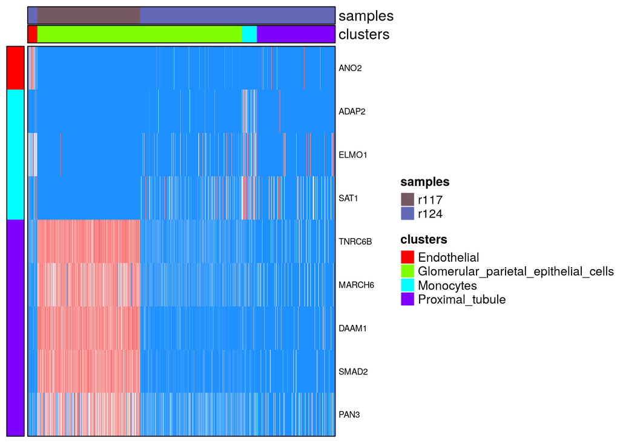

```r
cellannot <-ann_by_level1$annotation$l1
#Дифференциальная экспрессия для обнаруженных клеточных типов
de.info <- con$getDifferentialGenes(groups=cellannot, n.cores=4, append.auc=TRUE)
# К сожалениею для Glomerular_parietal_epithelial_cells не получилось найти дифф экспресию (из-за того что в образце 117 все клетки были отнесены к этому типу)
de <- list(Endothelial = de.info$Endothelial, Monocytes = de.info$Monocytes, Proximal_tubule = de.info$Proximal_tubule)


plotDEheatmap(con, as.factor(cellannot), de, n.genes.per.cluster = 5, column.metadata=list(samples=con$getDatasetPerCell()), row.label.font.size = 7, remove.duplicates=F)
```

```r
#функции генов
genes <- c("ANO2", "ADAP2", "ELMO1", "SAT1", "TNRC6B", "MARCH6", "SMAD2", "DAAM1", "PAN3")

function.gene <- mapIds(org.Hs.eg.db,
                     keys=genes,
                     column="GENENAME",
                     keytype="SYMBOL",
                     multiVals="first")
function.gene
```

```
##                                                  ANO2
##                                         "anoctamin 2"
##                                                 ADAP2
##                       "ArfGAP with dual PH domains 2"
##                                                 ELMO1
##                      "engulfment and cell motility 1"
##                                                  SAT1
##          "spermidine/spermine N1-acetyltransferase 1"
##                                                TNRC6B
##          "trinucleotide repeat containing adaptor 6B"
##                                                MARCH6
##                                                    NA
##                                                 SMAD2
##                                "SMAD family member 2"
##                                                 DAAM1
## "dishevelled associated activator of morphogenesis 1"
##                                                  PAN3
##          "poly(A) specific ribonuclease subunit PAN3"
```

Попробуем произвести классический анализ путей для данных рнк секвенирования. Сведем все клетки к 4 кластерам - клеточным типам.

```r
library(DESeq2)
library(gage)
library(gageData)

#Кластеризация данных, расчет генов для каждого клеточного типа
data_clusters <- conos:::collapseCellsByType(t(mat), ann_by_level1$annotation$l1, min.cell.count = 0)
countData <- t(data_clusters)


colData <- setNames(colnames(countData),  colnames(countData))
colData <- tibble(condition = colnames(countData))
rownames(colData) <- colnames(countData)

countData <- round(countData*10)
dds <- DESeqDataSetFromMatrix(countData=countData,
                              colData=colData, design=~1)
dds <-  DESeq(dds)
res <- results(dds)
res <- res[order(res$pvalue),]

res$ens <- mapIds(org.Hs.eg.db,
                     keys=row.names(res),
                     column="ENSEMBL",
                     keytype="SYMBOL",
                     multiVals="first")
res$entrez <- mapIds(org.Hs.eg.db,
                     keys=row.names(res),
                     column="ENTREZID",
                     keytype="SYMBOL",
                     multiVals="first")
res$name <-  mapIds(org.Hs.eg.db,
                     keys=row.names(res),
                     column="GENENAME",
                     keytype="SYMBOL",
                     multiVals="first")


data(kegg.sets.hs)
data(sigmet.idx.hs)
kegg.sets.hs <- kegg.sets.hs[sigmet.idx.hs]
foldchanges <- res$log2FoldChange
names(foldchanges) <- res$entrez

# Анализ путей
keggres <- gage(foldchanges, gsets=kegg.sets.hs, same.dir=TRUE)
lapply(keggres, head)
```

```
## $greater
##                                                         p.geomean stat.mean
## hsa04510 Focal adhesion                              8.639369e-23 10.441595
## hsa04144 Endocytosis                                 4.465489e-19  9.360275
## hsa04141 Protein processing in endoplasmic reticulum 1.171338e-18  9.437759
## hsa04810 Regulation of actin cytoskeleton            3.745381e-18  9.056448
## hsa03010 Ribosome                                    5.207169e-17  9.706836
## hsa04120 Ubiquitin mediated proteolysis              1.202245e-16  8.842102
##                                                             p.val        q.val
## hsa04510 Focal adhesion                              8.639369e-23 1.390938e-20
## hsa04144 Endocytosis                                 4.465489e-19 3.594719e-17
## hsa04141 Protein processing in endoplasmic reticulum 1.171338e-18 6.286181e-17
## hsa04810 Regulation of actin cytoskeleton            3.745381e-18 1.507516e-16
## hsa03010 Ribosome                                    5.207169e-17 1.676708e-15
## hsa04120 Ubiquitin mediated proteolysis              1.202245e-16 3.226024e-15
##                                                      set.size         exp1
## hsa04510 Focal adhesion                                   195 8.639369e-23
## hsa04144 Endocytosis                                      195 4.465489e-19
## hsa04141 Protein processing in endoplasmic reticulum      156 1.171338e-18
## hsa04810 Regulation of actin cytoskeleton                 198 3.745381e-18
## hsa03010 Ribosome                                          87 5.207169e-17
## hsa04120 Ubiquitin mediated proteolysis                   130 1.202245e-16
##
## $less
##                                                          p.geomean  stat.mean
## hsa04740 Olfactory transduction                       1.405904e-06 -4.8553715
## hsa04975 Fat digestion and absorption                 1.264154e-01 -1.1534216
## hsa00591 Linoleic acid metabolism                     2.028979e-01 -0.8390753
## hsa00830 Retinol metabolism                           2.157918e-01 -0.7897490
## hsa00140 Steroid hormone biosynthesis                 3.037935e-01 -0.5153825
## hsa00980 Metabolism of xenobiotics by cytochrome P450 3.287763e-01 -0.4444218
##                                                              p.val        q.val
## hsa04740 Olfactory transduction                       1.405904e-06 0.0002263506
## hsa04975 Fat digestion and absorption                 1.264154e-01 1.0000000000
## hsa00591 Linoleic acid metabolism                     2.028979e-01 1.0000000000
## hsa00830 Retinol metabolism                           2.157918e-01 1.0000000000
## hsa00140 Steroid hormone biosynthesis                 3.037935e-01 1.0000000000
## hsa00980 Metabolism of xenobiotics by cytochrome P450 3.287763e-01 1.0000000000
##                                                       set.size         exp1
## hsa04740 Olfactory transduction                             82 1.405904e-06
## hsa04975 Fat digestion and absorption                       35 1.264154e-01
## hsa00591 Linoleic acid metabolism                           25 2.028979e-01
## hsa00830 Retinol metabolism                                 50 2.157918e-01
## hsa00140 Steroid hormone biosynthesis                       45 3.037935e-01
## hsa00980 Metabolism of xenobiotics by cytochrome P450       60 3.287763e-01
##
## $stats
##                                                      stat.mean      exp1
## hsa04510 Focal adhesion                              10.441595 10.441595
## hsa04144 Endocytosis                                  9.360275  9.360275
## hsa04141 Protein processing in endoplasmic reticulum  9.437759  9.437759
## hsa04810 Regulation of actin cytoskeleton             9.056448  9.056448
## hsa03010 Ribosome                                     9.706836  9.706836
## hsa04120 Ubiquitin mediated proteolysis               8.842102  8.842102
```

```r
# Выберем 10 высходящих путей
keggrespathways <- data.frame(id=rownames(keggres$greater), keggres$greater) %>%
  tbl_df() %>%
  filter(row_number()<=10) %>%
  .$id %>%
  as.character()
```

Возможные активированные пути:

```r
keggrespathways
```

```
##  [1] "hsa04510 Focal adhesion"
##  [2] "hsa04144 Endocytosis"
##  [3] "hsa04141 Protein processing in endoplasmic reticulum"
##  [4] "hsa04810 Regulation of actin cytoskeleton"
##  [5] "hsa03010 Ribosome"
##  [6] "hsa04120 Ubiquitin mediated proteolysis"
##  [7] "hsa04722 Neurotrophin signaling pathway"
##  [8] "hsa04010 MAPK signaling pathway"
##  [9] "hsa04520 Adherens junction"
## [10] "hsa04380 Osteoclast differentiation"
```